# Multi Armed Bandit

### 3.6.3 *Softmax*

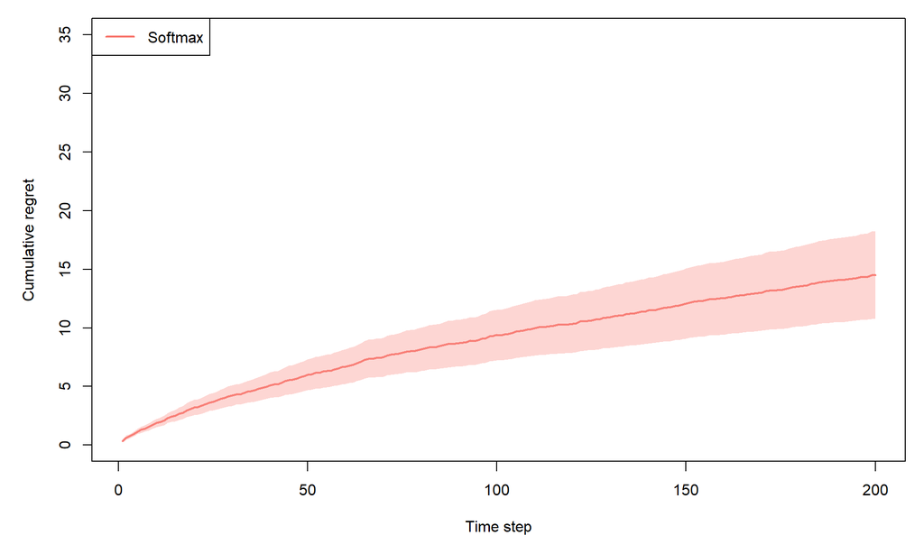

```r
plot(history,
     type = "cumulative",
     disp = "ci",
     ylim = c(0,35),
     limit_agents = "Softmax")
```

### 3.6.4 *Upper Confidence Bounds*

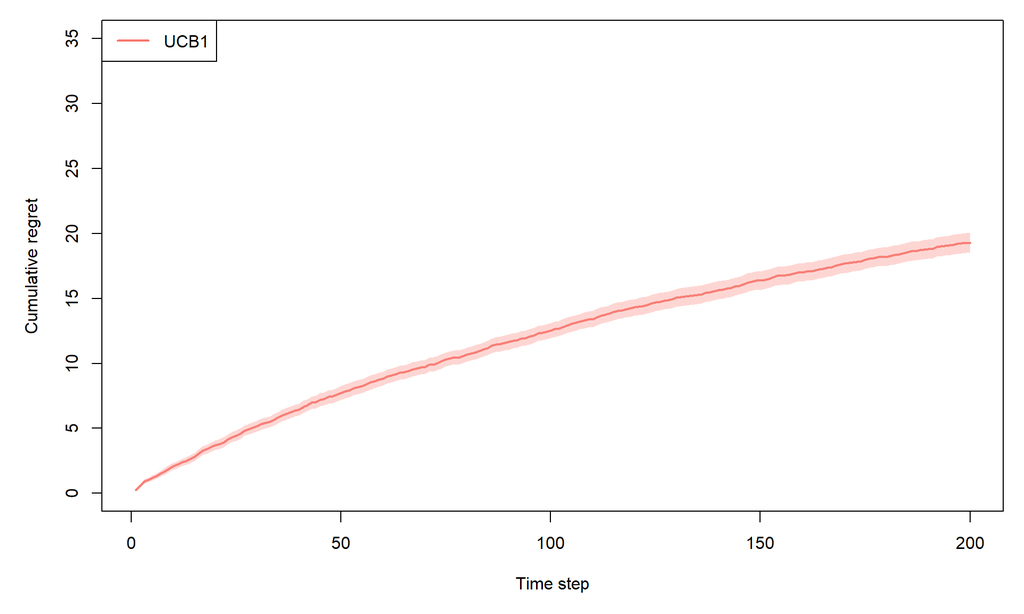

```r
plot(history,
     type = "cumulative",
     disp = "ci",
     ylim = c(0,35),
     limit_agents = "UCB1")
```

### 3.6.5 Thompson Sampling

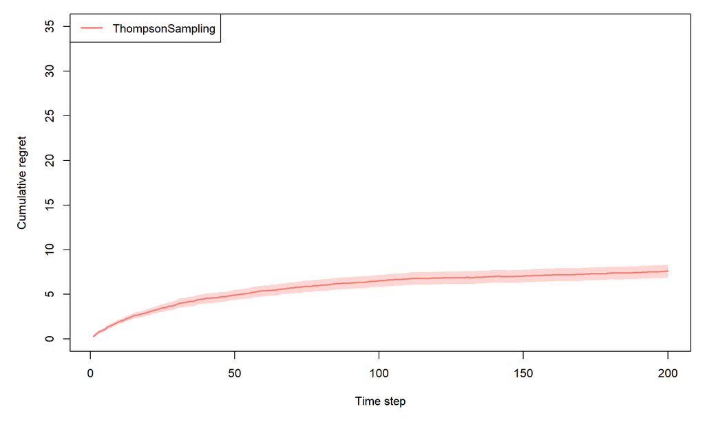

```r
plot(history,
     type = "cumulative",
     disp = "ci",
     ylim = c(0,35),
     limit_agents = "ThompsonSampling")
```

### 3.6.6 *Smooth Plot of Cumulative regret of All Agent*

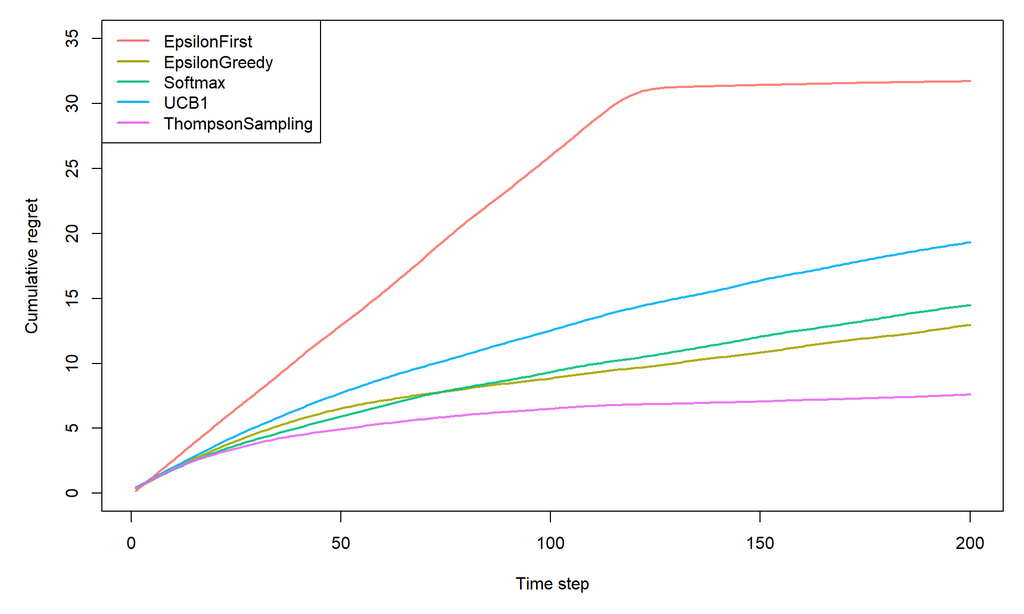

```r
plot(history,
     type = "cumulative",
     smooth = TRUE,
     ylim = c(0,35))
```

# 4 Catatan dan Rekomendasi

## 4.1 Komentar mengenai policy

*Policy policy* yang digunakan akan memiliki performa yang berbeda-beda tergantung jenis reward yang disajikan, bagaimana rentang waktu yang disediakan, ataupun seberapa berbeda reward masing masing *arm* (apakah hanya beda tipis? atau beda jauh?)

## 4.2 Filosofi *Multi-Armed Bandit* dalam kehidupan nyata

Diambil dari buku “Bandit Problems on Website Optimization, (John Wyles White 2012)”

- We only find out about the reward that was given out by the arm we actually pulled. Whichever arm we pull, we miss out on information about the other arms that we didn’t pull. Just like in real life, you only learn about the path you took and not the paths you could have taken.
- Not only do we get only partial feedback about the wisdom of our past decisions, we’re literally falling behind every time we don’t make a good decision: • Every time we experiment with an arm that isn’t the best arm, we lose reward because we could, at least in principle, have pulled on a better arm.
- In the real world, you always have to trade off between gathering data and acting on that data. Pure experimentation in the form of exploration is always a shortterm loss, but pure profit-making in the form of exploitation is always blind to the long-term benefits of curiosity and openmindedness.
- Everybody’s gotta grow up sometime You should make sure that you explore less over time. No matter what you’re doing, it’s important that you don’t spend your whole life trying out every crazy idea that comes into your head.

## 4.3 Beberapa ekstensi yang dapat digali

Problem *Multi-Armed Bandit* dapat di ekstensikan (sesuai famili yang diberikan pada awal notebook) untuk menyesuaikan problem problem yang ada, baik itu dari segi

- [Reward] Dapat dicoba distribusi reward lain, baik itu gaussian, poisson, ataupun bentuk rewardnya
- [Context] Reward yang diberikan akan bergantung terhadap siapa yang menarik *arm*, contohnya dalam konteks medis, obat merk tertentu mungkin akan lebih efektif pada pasien usia tua dibanding usia muda
- [Time-Varying] Distribusi *reward* tidak mesti stasioner, dapat saja berubah seiring percobaan berjalan, contohnya dalam konteks modifikasi website, citravisual tertentu mungkin akan lebih efektif pada saat menjelang natal, namun setelah itu, citravisual lain akan lebih cocok saat *event* lainnya
- [Kecepatan Feedback] *reward* yang diberikan pun tidak mesti diberikan pada saat *arm* ditarik (instant), dapat saja terdapat delay dalam penerimaan reward
- [Ensemble] Pemilihan *arm* didasarkan oleh agregat dari banyak *policy*, setiap *policy* dapat diberi bobot yang dapat di-*update* setiap *trial*-nya.
- [Multi-Player] Jika ada banyak pemain, jika ada skenario ketika ada lebih dari satu pemain menarik *arm* yang sama, hanya ada satu pemain yang mendapatkan *reward* atau bahkan semua pemain yang memilih *arm* yang sama tidak mendapatkan *reward* sama sekali.
- [Cost & Budget] Setiap *arm* dapat memiliki biaya masing masing yang mungkin berbeda untuk setiap kali penarikannya, sehingga perlu untuk menyusun strategi untuk menyesuaikan penarikan *arm* sesuai *budget* yang ada.
- [Dependent Arm] *Reward* yang diberikan dapat juga berbeda tergantung *sequence* penarikan yang dilakukan.

# 5 Referensi

- Bandit Algorithms for Website Optimization (John Myles White 2012)
- contextual: Evaluating Contextual Multi-Armed Bandit Problems in R (Robin van Emden, Maurits Kaptein 2020)
- contextual package documentation in R (Robin van Emden 2019)